# Assignment 2 Pooja Babu

Pooja Babu

2025-10-30

## Part A

**QA1**

**What is the key idea behind bagging?Can bagging deal both with high variance (overfitting) and high bias (underfitting)?**

Bagging, is an ensemble learning method used to make a model more accurate, reliable, and stable. It works by training several models on slightly different random samples of the data. These samples are taken with replacement, meaning some data points may appear more than once in a sample while others may not appear at all. Usually, about two-thirds of the total data is used in each sample, and the remaining one-third is called out-of-bag data, which can be used later to test how well the model performs.

Each small model, often called a weak learner, may not perform very well on its own, but when all of them are combined, the result is much stronger. For numerical predictions, their results are averaged, and for classification problems, the majority vote decides the final answer.

For bagging to work well, two criterias are very important. One is competence and the other one is diversity. Competence means that each small model should be better than random guessing and able to capture useful information from its training sample. Diversity means that each model should be slightly different from the others. This difference comes from the random sampling of data. When many such models are combined, the differences between them help cancel out individual errors. This makes the final ensemble model more stable and less likely to overfit.

Overfitting happens when a model learns the training data too well and does not work well on new data. Bagging trains many models on different random samples and then combines their results. This helps smooth out the random errors made by each model and makes the final prediction more stable and accurate. So, Bagging helps with high variance, which means it reduces overfitting.

Underfitting happens when a model is too simple and cannot learn the real patterns in the data. If all the models are weak and make the same mistakes, combining them will not make the results better. So, Bagging does not help with high bias, which means it cannot fix underfitting.

**QA2**

**Why bagging models are computationally more efficient when compared to boosting models with the same number of weak learners?**

Bagging models are computationally more efficient than boosting models because of the way they build and train their weak learners. In bagging, each model is trained separately on a random sample of the data. This process is called parallel training, meaning all the models can be trained at the same time without depending on one another. Since they are independent, the overall time taken to train multiple models is much less. If the computer has multiple processors or cores, bagging can use them all at once to complete the training faster.

In boosting, the models are trained in a sequence, one after the other. Each new model learns from the errors made by the previous model. This makes boosting slower because every next model must wait for the earlier one to finish before it can start learning. The process requires continuous adjustment of weights for the data points after every round, which adds extra steps and increases computation time.

Another reason bagging is more efficient is that it does not require as much fine-tuning during training. Each model simply learns from its random sample, while boosting involves more calculations to reduce bias by giving more focus to difficult cases.

In simple terms, bagging is faster and easier to compute because it can train all models at once and does not rely on earlier models, while boosting is slower since it trains each model one by one and constantly updates based on past mistakes.

**QA3**

**James is thinking of creating an ensemble mode to predict whether a given stock will go up or down in the next week. He has trained several decision tree models but each model is not performing any better than a random model. The models are also very similar to each other. Do you think creating an ensemble model by combining these tree models can boost the performance? Discuss your answer.**

Creating an ensemble from James’s weak and similar decision tree models will not improve the prediction results. Ensemble learning methods such as bagging, boosting, or random forests work best when the individual models are diverse and have at least some predictive power.

Here, each of James’s trees performs no better than random guessing, which means they are not learning any real patterns from the data. On top of that, they are very similar to one another, meaning they will likely make the same errors. For an ensemble to work properly, the base models must be both accurate and diverse. Accuracy means that each model performs better than random, while diversity means that each model captures slightly different aspects of the data.

So, before creating an ensemble, James should focus on improving his individual models and making them more diverse. He can do this by changing model parameters like tree depth or split criteria, using random subsets of features as in random forests, or trying boosting to focus more on the data points that were previously misclassified. Only after these steps will an ensemble model have a real chance to perform better.

So, combining weak and similar models will not boost accuracy. For ensemble learning to work, the models must each contribute something unique. James should first strengthen and diversify his models before building an ensemble if he wants to see a meaningful improvement in prediction performance.

**QA4**

**Consider the following Table that classifies some objects into two classes of edible (+) and non- edible (-), based on some characteristics such as the object color, size and shape. What would be the Information gain for splitting the dataset based on the “Size” attribute?**

Total Number of samples = 16.

Edible Vs Non-Edible

Edible (++) = 9 Non-Edible (–) = 7

Based on size,

Small: 8 samples (6 edible, 2 non-edible) Large: 8 samples (3 edible, 5 non-edible)

Entropy Measures the level of impurity in a group of data samples.

Entropy (S) = −p (+)log2(p+) −p −log2(p−)

where, S is the sample training data.

p(+) is the proportion of edible objects in S

p(−) is the proportion of non-edible objects in S

Information Gain tells us how important a given attribute of the feature vectors is.

Information Gain = entropy(parent) - [average entropy(children)]

Calculating Parent Entropy :

```r
parent_entropy <- -(9/16)*log2(9/16) - (7/16)*log2(7/16)
parent_entropy
```

```
## [1] 0.9886994
```

Calculating child entropy for each subset :

```r
#Small Size

small_entropy <- -(6/8)*log2(6/8) - (2/8)*log2(2/8)
small_entropy
```

```
## [1] 0.8112781
```

```r
#Large Size

large_entropy <- -(3/8)*log2(3/8) - (5/8)*log2(5/8)
large_entropy
```

```
## [1] 0.954434
```

Calculating Information Gain

```r
Information_gain <- parent_entropy - (8/16) * large_entropy - (8/16) * small_entropy

Information_gain
```

```
## [1] 0.1058433
```

Therefore, The information gain for splitting the dataset based on “Size” attribute is 0.105. A higher information gain means the attribute can separate edible and non-edible items more clearly. Since the information gain for “Size” is small, it means that “Size” alone is not very helpful in deciding if something is edible or not.

**QA5**

**Why is it important that the m parameter (number of attributes available at each split) to be optimally set in random forest models? Discuss the implications of setting this parameter too small or too large.**

In a Random Forest model, the m parameter controls how many features are allowed to compete for a split at each node of each tree. This number is very important because it controls a balance between two things. First, how strong each individual tree can be. Second, how different the trees are from one another. The overall performance of the forest depends on getting both of these right at the same time.

If m is chosen too small, each split in a tree is allowed to look at only a very small number of features. This makes the trees more different from each other, because they are forced to use different feature subsets. That extra diversity is good, since it reduces correlation between trees and helps the averaging step. However, the cost is that many splits will not see the best or most informative features at all. As a result, each tree can become a weaker learner and the forest may start to underfit. In other words, the model may have higher bias and lower accuracy because the trees are not using enough useful information at each split.

If m is chosen too large, the opposite problem appears. When each split can see many features or even all of them, then most trees will tend to pick the same strong predictors again and again. Individual trees may look stronger on their own, but the forest as a group becomes less diverse. The trees start to look similar and make similar mistakes. This increases correlation between the trees and reduces the benefit of averaging their predictions. In practice this can bring back more variance and make the model more likely to overfit, especially when the trees are deep.

So m needs to be set to a value that gives a good trade off. It must be large enough so that splits can use informative features and build competent trees, but small enough so that different trees still explore different parts of the feature space and keep good diversity. Tuning m carefully helps the Random Forest achieve low variance without pushing bias too high, which leads to better generalization on new data.

## Part B

```r
# Load libraries
library(ISLR)
library(dplyr)
library(glmnet)
library(caret)
```

```r
library(rpart)
library(rpart.plot)
library(randomForest)
set.seed(123)  # for anything that uses randomness later

# Keep only the needed columns
Carseats_Filtered <- Carseats %>%
  dplyr::select(Sales, Price, Advertising, Population, Age, Income, Education)

# Take a quick look
head(Carseats_Filtered)
```

```
##   Sales Price Advertising Population Age Income Education
## 1  9.50   120          11        276  42     73        17
## 2 11.22    83          16        260  65     48        10
## 3 10.06    80          10        269  59     35        12
## 4  7.40    97           4        466  55    100        14
## 5  4.15   128           3        340  38     64        13
## 6 10.81    72          13        501  78    113        16
```

```r
str(Carseats_Filtered)
```

```
## 'data.frame':    400 obs. of  7 variables:
##  $ Sales      : num  9.5 11.22 10.06 7.4 4.15 ...
##  $ Price      : num  120 83 80 97 128 72 108 120 124 124 ...
##  $ Advertising: num  11 16 10 4 3 13 0 15 0 0 ...
##  $ Population : num  276 260 269 466 340 501 45 425 108 131 ...
##  $ Age        : num  42 65 59 55 38 78 71 67 76 76 ...
##  $ Income     : num  73 48 35 100 64 113 105 81 110 113 ...
##  $ Education  : num  17 10 12 14 13 16 15 10 10 17 ...
```

**Question B 1**

**Building a decision tree regressio model to predict Sales**

```r
# Fitting regression tree model
tree_model <- rpart(
  formula = Sales ~ Price + Advertising + Population + Age + Income + Education,
  data = Carseats_Filtered,
  method = "anova"
)
```

```r
summary(tree_model)
```

```
## Call:
## rpart(formula = Sales ~ Price + Advertising + Population + Age +
##     Income + Education, data = Carseats_Filtered, method = "anova")
##   n= 400
##
##            CP nsplit rel error    xerror       xstd
## 1  0.14251535      0 1.0000000 1.0063165 0.06963484
## 2  0.08034146      1 0.8574847 0.9159590 0.06531010
## 3  0.06251702      2 0.7771432 0.8840071 0.06507510
## 4  0.02925241      3 0.7146262 0.8264811 0.05974859
## 5  0.02537341      4 0.6853738 0.8251007 0.05677601
## 6  0.02127094      5 0.6600003 0.8329759 0.05626529
## 7  0.02059174      6 0.6387294 0.8443029 0.05786670
## 8  0.01632010      7 0.6181377 0.8420832 0.05750353
## 9  0.01521801      8 0.6018176 0.8264536 0.05528371
## 10 0.01042023      9 0.5865996 0.8551362 0.05717815
## 11 0.01000559     10 0.5761793 0.8736311 0.05778555
## 12 0.01000000     12 0.5561681 0.8858429 0.05833926
##
## Variable importance
##       Price Advertising         Age      Income  Population   Education
##          49          18          16           8           6           3
##
## Node number 1: 400 observations,    complexity param=0.1425153
##   mean=7.496325, MSE=7.955687
##   left son=2 (329 obs) right son=3 (71 obs)
##   Primary splits:
##       Price       < 94.5  to the right, improve=0.14251530, (0 missing)
##       Advertising < 7.5   to the left,  improve=0.07303226, (0 missing)
##       Age         < 61.5  to the right, improve=0.07120203, (0 missing)
##       Income      < 61.5  to the left,  improve=0.02840494, (0 missing)
##       Population  < 174.5 to the left,  improve=0.01077467, (0 missing)
##
## Node number 2: 329 observations,    complexity param=0.08034146
##   mean=7.001672, MSE=6.815199
##   left son=4 (174 obs) right son=5 (155 obs)
##   Primary splits:
##       Advertising < 6.5   to the left,  improve=0.11402580, (0 missing)
##       Price       < 136.5 to the right, improve=0.08411056, (0 missing)
##       Age         < 63.5  to the right, improve=0.08091745, (0 missing)
```

[output cut: 162 more lines]

```
##   Surrogate splits:
##       Education   < 12.5  to the right, agree=0.676, adj=0.267, (0 split)
##       Advertising < 7.5   to the right, agree=0.647, adj=0.200, (0 split)
##       Age         < 53.5  to the left,  agree=0.647, adj=0.200, (0 split)
##       Population  < 240   to the right, agree=0.618, adj=0.133, (0 split)
##       Income      < 41.5  to the right, agree=0.618, adj=0.133, (0 split)
##
## Node number 47: 64 observations
##   mean=9.529375, MSE=4.5078
##
## Node number 92: 19 observations
##   mean=6.751053, MSE=3.378915
##
## Node number 93: 15 observations
##   mean=9.154667, MSE=3.273025
```

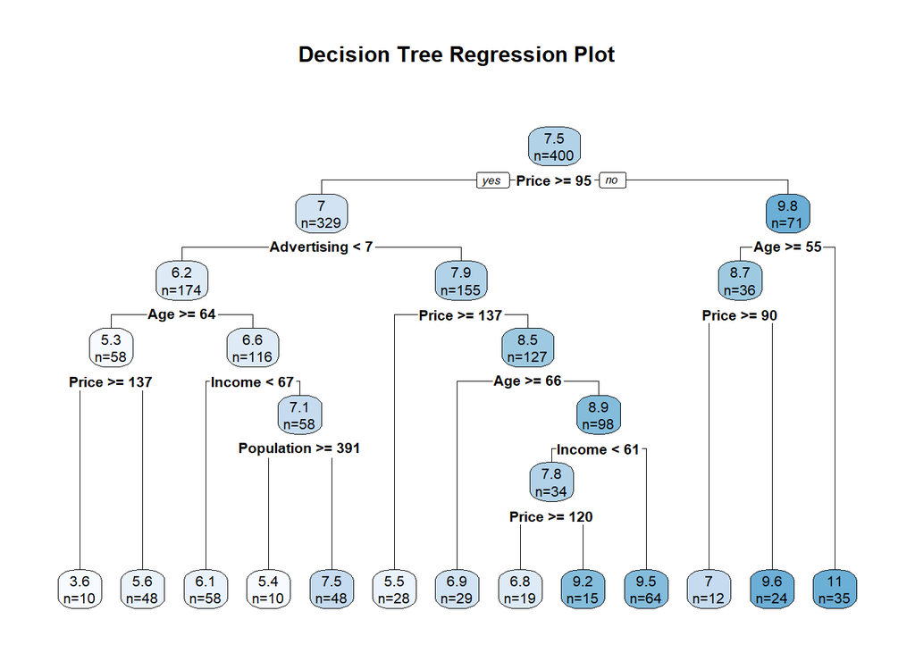

```r
# Visualizing the tree
rpart.plot(tree_model,
           type = 2,
           extra = 1,
           main = "Decision Tree Regression Plot")
```

The decision tree model was formed for predicting Sales. The top node is the root node, and based on this model, the Price attribute is chosen as a splitting variable. When the model tested all the predictors, it found that splitting the data by Price created the biggest decrease in variance. This means that when the data was divided based on Price, the resulting groups had much more consistent sales within them compared to splits made using any other variable.

From the model, we can see that Price explains the biggest part of the differences in sales across stores. Stores with lower prices usually have higher sales, while stores with higher prices have lower sales. Because this pattern was the strongest and most consistent, the algorithm chose Price as the root node, or the first decision point in the tree. After Price, the model uses Advertising as the next splitting variable, showing that higher advertising spending generally leads to increased sales for stores within similar price ranges.

Therefore, Price is the most important variable at the first level of the model, it provides the most useful information for predicting sales and sets the foundation for all the other splits that come later.

**Question B 2**

**Estimating the Sales using the decision tree model**

```r
# Creating a new dataframe with values added for each variable
test_sales <- data.frame(
  Price = 6.54,
  Advertising = 0,
  Population = 124,
  Age = 76,
  Income = 110,
  Education = 10
)

#Predicting sales using decision tree model
predicted_sales_tree <- predict(tree_model, test_sales)

cat("Predicted Sales from Decision Tree Model is \n", predicted_sales_tree, "\n")
```

```
## Predicted Sales from Decision Tree Model is
##  9.58625
```

Using the fitted decision tree model, the given input record with a Price of 6.54, Advertising of 0, Population of 124, Age of 76, Income of 110, and Education of 10 was used to estimate the Sales value. The model predicted a Sales value of approximately 9.59, while the actual value is 9. This small difference shows that the model’s prediction is very close to predicting the actual values if tested in real life data.

**Question B 3**

**Training a random forest using caret library default settings**

```r
set.seed(123)

#Fitting a random forest model
rf_fit_default <- train(
  Sales ~ Price + Advertising + Population + Age + Income + Education,
  data = Carseats_Filtered,
  method = "rf"
)


rf_fit_default
```

```
## Random Forest
##
## 400 samples
##   6 predictor
##
## No pre-processing
## Resampling: Bootstrapped (25 reps)
## Summary of sample sizes: 400, 400, 400, 400, 400, 400, ...
## Resampling results across tuning parameters:
##
##   mtry  RMSE      Rsquared   MAE
##   2     2.405819  0.2852547  1.926801
##   4     2.421577  0.2790266  1.934608
##   6     2.447373  0.2681323  1.953147
##
## RMSE was used to select the optimal model using the smallest value.
## The final value used for the model was mtry = 2.
```

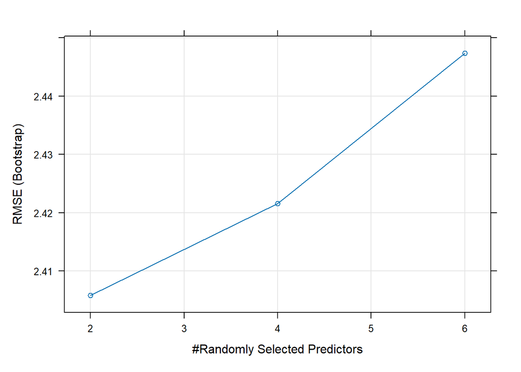

```r
plot(rf_fit_default)
```

For the random forest model,the caret train() function was used with method = “rf” to predict Sales from Price, Advertising, Population, Age, Income, and Education. caret automatically tried different values of mtry, which is the number of predictors randomly considered at each split in the forest. The results show that mtry = 2 produced the lowest RMSE (2.4058), compared to mtry = 4 and mtry = 6, which had higher RMSE values. Since a lower RMSE means better predictive performance, caret selected mtry = 2 as the best tuning parameter. Therefore, the best-performing random forest model uses mtry = 2.

**Question B 4**

**Customize the search grid by checking the model’s performance for mtry values of 2, 3 and 5 using 3 repeats of 5-fold cross validation.**

```r
set.seed(123)

# Setting up cross validation
ctrl_custom <- trainControl(
  method  = "repeatedcv",
  number  = 5,
  repeats = 3
)

#Customising the tuning grid for mtry values
grid_custom <- expand.grid(
  mtry = c(2, 3, 5)
)

#Training Random forest model
rf_fit_custom <- train(
  Sales ~ Price + Advertising + Population + Age + Income + Education,
  data = Carseats_Filtered,
  method = "rf",
  trControl = ctrl_custom,
  tuneGrid  = grid_custom
)

rf_fit_custom
```

```
## Random Forest
##
## 400 samples
##   6 predictor
##
## No pre-processing
## Resampling: Cross-Validated (5 fold, repeated 3 times)
## Summary of sample sizes: 320, 321, 319, 320, 320, 319, ...
## Resampling results across tuning parameters:
##
##   mtry  RMSE      Rsquared   MAE
##   2     2.405235  0.2813795  1.930855
##   3     2.401365  0.2858295  1.920612
##   5     2.417771  0.2821938  1.934886
##
## RMSE was used to select the optimal model using the smallest value.
## The final value used for the model was mtry = 3.
```

```r
rf_fit_custom$results
```

```
##   mtry     RMSE  Rsquared      MAE    RMSESD RsquaredSD     MAESD
## 1    2 2.405235 0.2813795 1.930855 0.1397067 0.07045629 0.1267538
## 2    3 2.401365 0.2858295 1.920612 0.1312240 0.07292783 0.1186103
## 3    5 2.417771 0.2821938 1.934886 0.1305817 0.07458604 0.1197954
```

```r
rf_fit_custom$bestTune
```

```
##   mtry
## 2    3
```

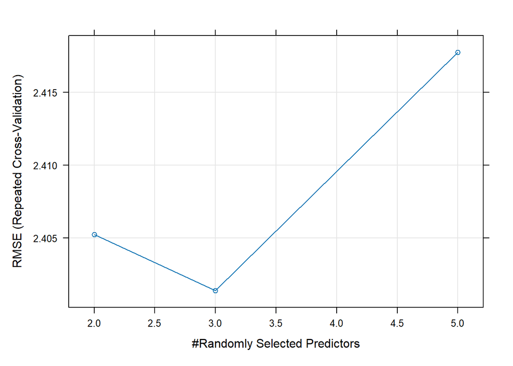

```r
plot(rf_fit_custom)
```

A random forest regression model was trained using the caret package with a custom tuning grid that evaluated three different mtry values (2, 3, and 5). The model used 3 repeats of 5-fold cross-validation to ensure a more reliable estimate of performance. The results showed that mtry = 3 produced the lowest RMSE (2.401) and the highest R-squared (0.2858) among the tested values, indicating the best predictive accuracy. Therefore, the optimal number of variables randomly sampled at each split for this dataset is mtry = 3. This tuning approach confirms that using a moderate number of predictors at each split leads to better model generalization compared to smaller or larger values of mtry.